# Hierarchical RL Bayesian Analysis

Valeria Avino

2025-06-23

# Introduction

This project analyzes human behavior in a **reinforcement learning** (RL) task using a **Bayesian hierarchical modeling** framework. The dataset, sourced from the behavioral study by [Gershman et al. (2015)](https://doi.org/10.1016/j.jmp.2021.102602), investigates reinforcement-driven decision-making using a two-armed bandit task. The dataset provides trial-by-trial records of choices and outcomes across multiple participants and experiments.

### Task design

Each trial proceeds as follows:

1. A **stimulus** (one of four possible visual cues) is presented to one of the 205 subjects;
2. The participant chooses between two options: **left (1)** or **right (2)**, (based on the choice they “feel” will be rewarded);
3. A **reward** is delivered (1 = rewarded, 0 = not rewarded), drawn from a fixed probabilistic distribution specific to that stimulus.

Participants needed to learn, through trial and error, which option is more rewarding for each stimulus (4 different stimuli per subject, experienced in randomized order).

The dataset includes the choices and outcomes of **100 trials** across **205 participants**, for a total of 20,500 records. After the pre-processing (applied in the `preprocessing.R` script) the resulting `rl_data.RData` dataset:

Summary of Main Features in the RL Dataset

| Feature | Value |
| --- | --- |
| Number of subjects | 205 |
| Number of trials per subject | 100 |
| Total number of trials | 20500 |
| Number of stimuli | 4 |
| Stimulus IDs | 1, 2, 3, 4 |
| Number of choices | 2 |
| Choice options | 1, 2 |
| Missing values in key columns | None |

```
## Preview of the cleaned dataset
```

```
##      prob c r   N name trial_number game stick choice_two
## 1116  0.8 2 0 100    1            1    1   0.0          0
## 2197  0.8 1 0        1            2    1  -0.5          1
## 3106  0.8 1 1        1            3    1   0.5          1
## 4116  0.8 1 1        1            4    1   0.5          1
## 5126  0.8 1 0        1            5    1   0.5          1
## 6136  0.8 2 0        1            6    1   0.5          0
```

- `prob`: Underlying reward probability of the chosen action
- `c`: Choice made (1 = left, 2 = right)
- `r`:Binary reward received (1 = reward, 0 = no reward) $\sim$ Bernoulli(`prob`)
- `N`: Total number of trials (used for data cleaning)
- `name`: Subject identifier
- `trial_number`: Trial index (1–100)
- `game`/ `stim_id`: visual cue identifier (1–4)
- `stick`: bias toward repeating the previous choice, **independent of reward history**

- `choice_two` : binary choice made (1 = left, 0 = right)

Observation:

The `prob` column contains the **reward probability assigned to the chosen option** on each trial. This is **not** a probability prediction from the model, but rather a property of the experimental environment — it encodes the likelihood that a particular choice will be rewarded in that stimulus block. While not used directly in the JAGS models, it is useful for exploratory analysis and visualizing **true vs. learned reward structures**.

The `stim` variable indexes the **block** or **stimulus context**. Each stimulus is associated with a fixed pair of reward probabilities (e.g., left = 0.2, right = 0.8) over 25 trials.

The primary goal is to understand and quantify **how humans learn from feedback** and adapt their choices over time. To achieve this, three alternative models that capture plausible cognitive strategies, grounded in **Q-learning** are developed and estimated.

### Inferential Questions

The key inferential objectives are to:

- **Model subject-level cognitive strategies**
- **Quantify learning rates, biases and value difference sensitivity**
- **Establish if consecutive trial dependencies affect cognitive strategies**

## Exploratory Data Analysis

To justify the interest of the analysis and motivate models’ parameters we may investigate the nature of the dataset.

### Switching Behaviour

To explore whether participants adjusted their behavior based on **reward feedback** — a key feature of reinforcement learning — we examined trial-by-trial **switching behavior**.

Specifically, we can compute each subject’s **probability of switching choices depending on whether the previous trial was rewarded**. We are estimating the following conditional probabilities:
$$\mathbb{P}(c_{t+1}\neq x|
c_t=x, r_t=0)$$
$$\mathbb{P}(c_{t+1}\neq x| c_t=x,
r_t=1)$$

Subjects who learn from reward are expected to repeat actions that led to a reward and switch more often after unrewarded outcomes.

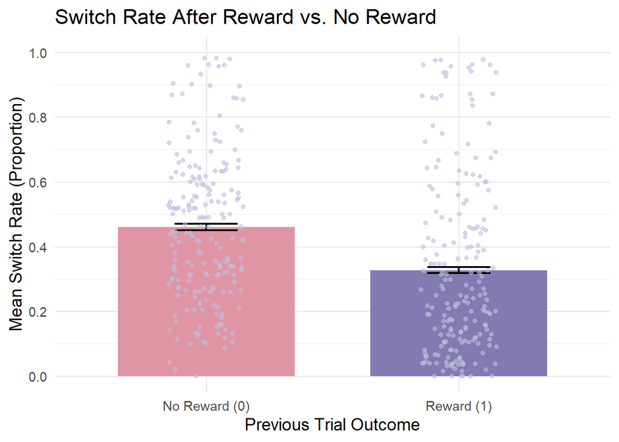

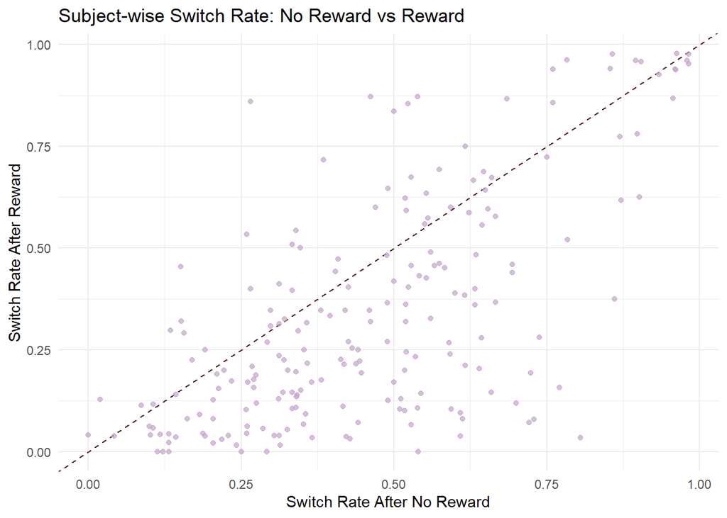

The plot shows that, on average across trials, subjects are **less likely to switch their choice after receiving a reward**. This indicates that **rewards reinforce the previous decision** — when a choice is rewarded, participants tend to stick with it in the next trial, suggesting that learning has occurred.

The wide vertical spread of dots within each bar visually confirms that individual subjects have very different switch rates. This extreme variability between individuals is strong evidence for why the **hierarchical** model is necessary, as it **allows parameters** like the learning rate ($\alpha$) **to vary across subjects**.

The second plot better captures **per-subject** switch rates following rewarded and unrewarded trials. It confirms that the majority of subjects shows a **lower switch rate after receiving a reward**, indicating **learning-driven** behavior.

Such exploratory analysis indicates sensitivity to feedback. This supports the inclusion of a **learning rate** parameter in our model to capture individual differences in how strongly participants update their value estimates based on recent outcomes.

### Learning curves

We may investigate the reward distribution and check if it tends to improve over time, i.e. if, on the group-level, subjects tend to learn over trials.

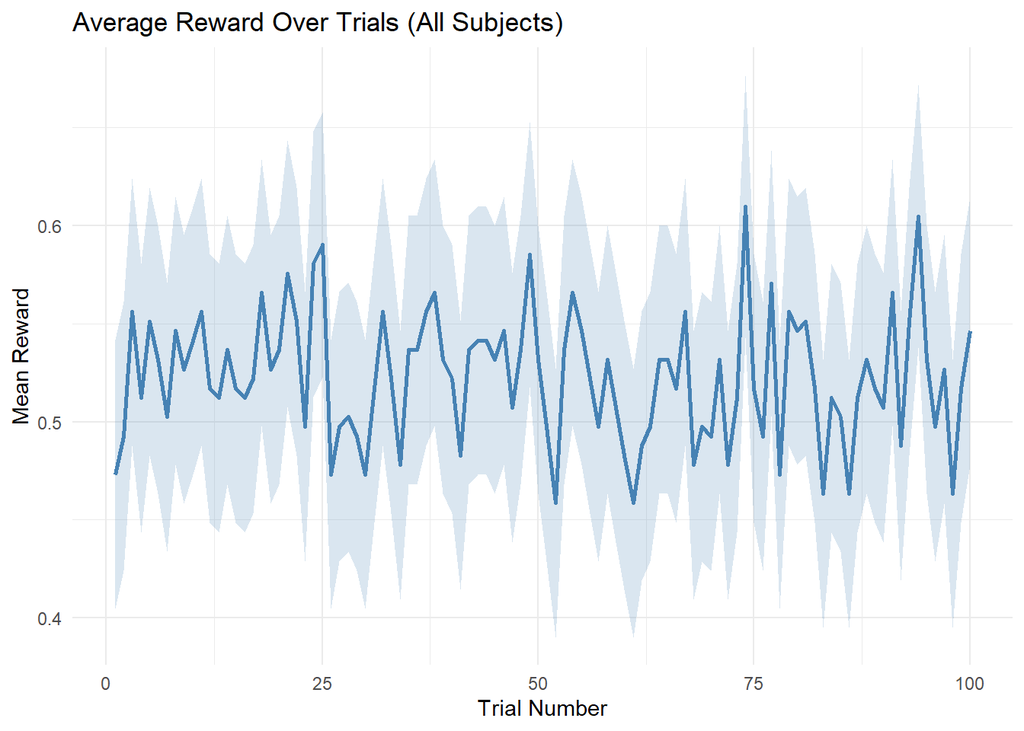

Looking at the graph, the mean reward curve fluctuates around $0.5$ throughout the $100$ trials, staying mostly between $0.45$ and $0.55$. As the reward is binary ($0$ or $1$), the mean reward on any given trial effectively represents the **proportion of subjects receiving a reward** of $1$. The shaded *confidence interval* is quite wide, indicating substantial *subject-to-subject variability* around the mean at any given trial.

This aggregate view, while informative, reveals no strong upward trend in mean reward over the $100$ trials, suggesting that, on average, the group did not exhibit a clear or consistent improvement in performance throughout the experiment. The wide confidence band surrounding the mean highlights substantial variability in reward outcomes across subjects at any given trial, hinting at underlying individual differences.

To delve deeper into this observed heterogeneity, we should look at the following Individual Subject Reward Over Trials plots for a random selection of participants (given the high number ogìf subjects).

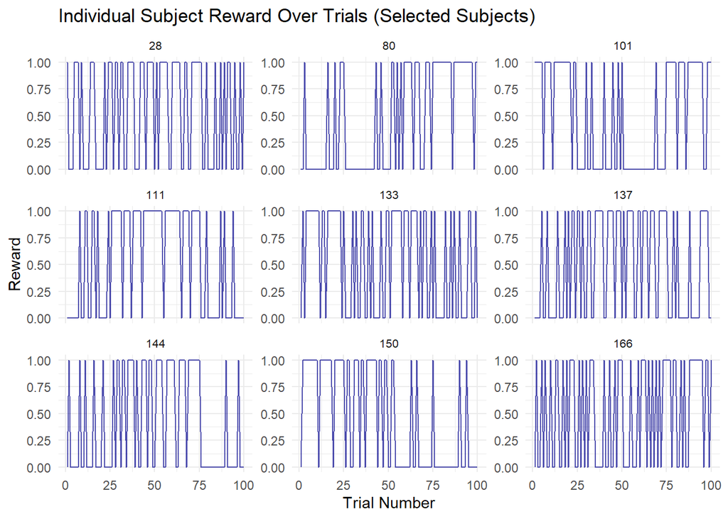

These plots vividly demonstrate the trial-by-trial sequence of binary rewards for each individual. Crucially, they confirm the presence of considerable **individual-level variability**, with participants exhibiting diverse and often ‘noisy’ reward sequences. The absence of consistently smooth learning curves within individuals, characterized by frequent oscillations between 0 and 1 rewards, underscores the challenges inherent in accurately estimating individual cognitive parameters from such data.

This justifies the need for a statistical pooling of information across subjects: if we tried to fit a non-hierarchical model to each subject’s data independently, the resulting parameter estimates for $\alpha$ and $\beta$ would likely be very unstable due to the “noisy” nature of these individual reward sequences. The hierarchical model will provide more robust estimates by leveraging the group data.

### Choice Distribution

To investigate whether participants exhibited an overall **preference** for one option regardless of recent outcomes, we can analyze the distribution of **choice proportions** across subjects.

If choices were purely driven by value learning, we would expect the average selection rates of each option to vary over time (i.e. over trial), but not consistently favor one side across participants.

We can examine whether participants exhibited a **systematic bias** toward one option by computing the proportion of choices made to each option ($1$ = Left, $2$ = Right) across all subjects.

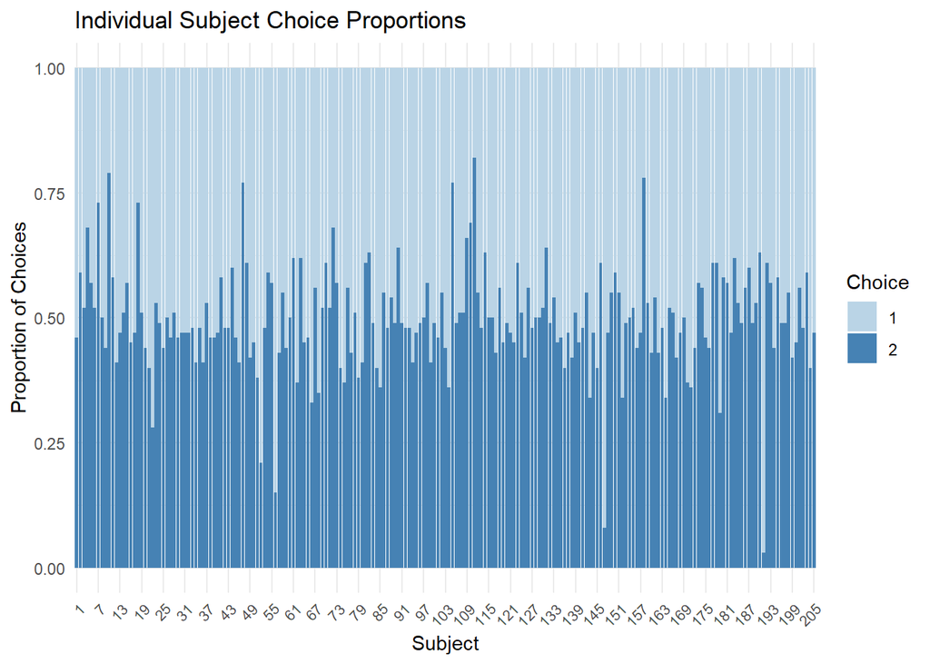

The stacked bar chart visually represents the proportion of times each participant selected *Choice 1* (Left) versus *‘Choice 2’* (Right) across all trials. Each vertical bar corresponds to a unique subject, and the height of the colored segments within the bar indicates the relative frequency of each choice for that specific individual.

Rather than a uniform distribution of choices (e.g., $50/50$ split), we observe a **spectrum of preferences**. Such clear visual evidence of **individual choice biases** strongly supports the model’s design, particularly the design of a subject-specific models, and the inclusion of an individual **intercept term**, to which we will refer as bias, or $b_0$. A positive $b_0$ would indicate a bias towards the “default” choice, while a negative $b_0$ would suggest a bias towards the alternative choice.

### Choice Preservation

Human decision-making is often more complex than just a static, unconditional bias. Participants don’t always restart their decision process anew on every trial, solely driven by learned values and a fixed baseline preference. Instead, their **previous actions** can exert an **influence** on their **current decision**, as emerges from the visualization below, which highlights the group-level probabilities
$$\mathbb{P}(c_{t+1}=x|c_t = 1)$$
$$\mathbb{P}(c_{t+1}=x|c_t = 2)$$

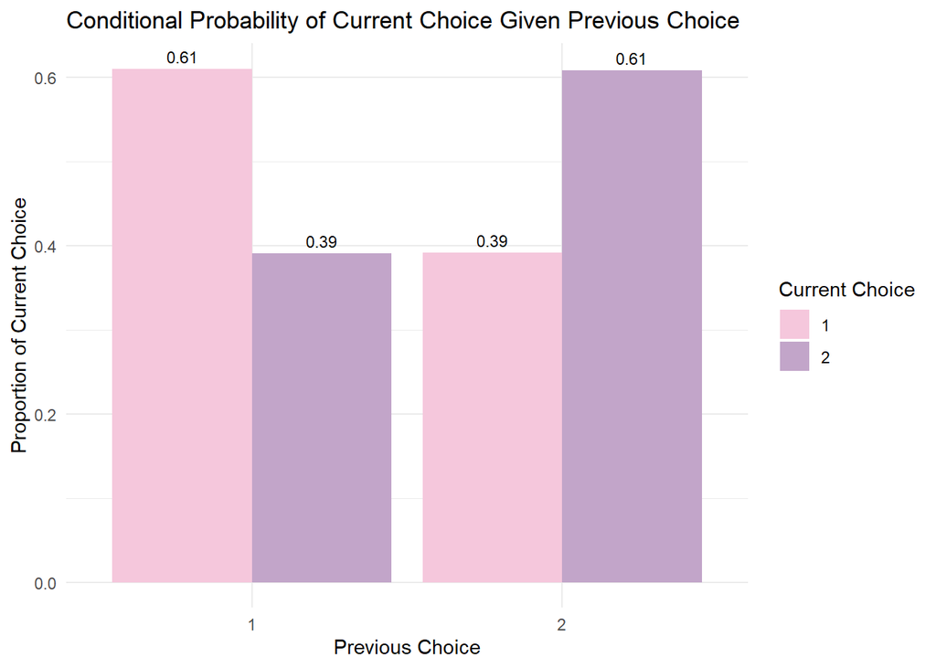

On average, the conditional probability of choosing the same option as the previous one is always higher then the alternative.

Such phenomenon of **choice preservation** is known as **stickiness*, and as the plot shows, it emerges even at the group-level: subjects tend to be conditioned by their previous decision when performing the current one.

Stickiness directly models a **conditional probability** – specifically, the probability of making a certain choice at trial $t+1$, given the choice made at trial $t$:
$$\mathbb{P}(\text{choice}_{t+1}|\text{choice}_t)$$

# Methods and Models

This project applies a **model-based Bayesian approach** to analyze human decision-making in a reinforcement learning (RL) task. We implement and compare three variants of the **Q-learning model**, designed to capture how participants learn from reward feedback and make binary choices. All models are implemented in **JAGS** and estimated via **Markov Chain Monte Carlo (MCMC)** using the `R2jags` interface in R.

At the core of Q-learning is the **action-value function** $Q_{s,t}(c)$, which represents the expected reward for taking choice $c \in \{1=\text{ left }, 2 =\text{right}\}$ at trial $t$ for subject $s$. These Q-values are initialized at $0.5$ and updated after each trial using a **prediction error**:

$$Q_{s,t+1}(c) = Q_{s,t}(c) + \alpha_s \cdot \delta_{s,t}
\quad\text{where}\quad
\delta_{s,t} = R_{s,t} - Q_{s,t}(c)$$

Here, $R_{s,t}$ is the reward received at trial $t$, and $\alpha_s$ is the **learning rate**, controlling how strongly prediction errors influence future expectations.

To model choice behavior, we define the **probability of choosing left** as a logistic function of the **value difference** $\Delta Q_{s,t}$ between the two actions:

$$\Delta Q_{s,t} = Q_{s,t}(1) - Q_{s,t}(2)$$

The choice probability is then:

$$\theta_{s,t} = \text{logit}^{-1}(\beta_{0,s} + \beta_{1,s} \cdot \Delta
Q_{s,t})
= \frac{1}{1 + \exp(-\beta_{0,s} - \beta_{1,s} \cdot \Delta Q_{s,t})}$$

Where:

- $\beta_{0,s}$ is a **bias term**, representing a subject’s baseline preference for the left option;
- $\beta_{1,s}$ is the **inverse temperature**, reflecting the degree of stochasticity in decision-making: high values lead to more deterministic choices based on $\Delta Q$, while low values lead to more random responses.

The **observed choice** for a subject $s$ at trial $t$ is modeled as:

$$\text{c}_{s,t} \sim \text{Bernoulli}(\theta_{s,t})$$

here $\theta_{s,t} = \mathbb{P}(c_{s,t} = 1)$ is governed by the former logistic function of the Q-value difference.

#### Likelihood for a Single Choice

The probability of observing a single choice $c_{s,t}$ for subject s at trial t is given by the Bernoulli probability mass function:

$$P(c_{s,t} | \alpha_s, \beta_{0,s},
\beta_{1,s}, Q_{s,t}(1), Q_{s,t}(2), R_{s,t}) = \theta_{s,t}^{c_{s,t}}
(1 - \theta_{s,t})^{1 - c_{s,t}}$$
#### Total Likelihood for the Dataset The total likelihood for the entire dataset, assuming choices are conditionally independent given the parameters, is the product of the likelihoods for all individual choices:

$$L(\text{data} | \alpha, \beta_0,
\beta_1) = \prod_{s=1}^{205} \prod_{t=1}^{100} P(c_{s,t} | \alpha_s,
\beta_{0,s}, \beta_{1,s}, Q_{s,t}(1), Q_{s,t}(2), R_{s,t})$$

This probabilistic formulation allows us to estimate each subject’s learning and decision parameters based on their observed behavior. The Bayesian framework supports full posterior inference and naturally extends to hierarchical structures to capture individual differences in cognitive strategies.

To prepare the dataset for Bayesian modeling in JAGS, we reshaped the trial-level data into **subject-by-trial** matrices ($205 \times 100$ dimensions), by looping over each trial for each subject and populating the matrices accordingly.

The key objects created and passed to the JAGS model via the `data_jags` list include:

- `trialNum_Gershman`: A vector indicating the total number of trials for each subject.
- `reward_Gershman`$_{i,j}$: Binary reward (1 or 0) received by the $i^{th}$ subject on the $j^{th}$ trial.
- `state_Gershman`$_{i,j}$: Stimulus identifier (1–4) presented to the $i^{th}$ subject on the $j^{th}$ trial.
- `choice_Gershman`$_{i,j}$: Original choice (1 = left, 2 = right) made by the $i^{th}$ subject on the $j^{th}$ trial.
- `choice_two_Gershman`$_{i,j}$: Binarized choice (1 = left, 0 = right) derived from `choice_Gershman`, used as the dependent variable for softmax regression.
- `stickiness_Gershman`$_{i,j}$: variable representing the influence of the previous choice. It is set to 0.5 if the $i^{th}$ subject’s previous choice was left, and -0.5 if the previous choice was right. For the first trial of each subject, this value is set to 0, as there is no preceding choice.

These prepared matrices, along with constants like the number of subjects and trials, form the `data_jags` object for the JAGS inference. Full preprocessing code is available in the supplementary script `preprocessing.R`.

## Model 1: Non-Hierarchical Q-Learning

Model 1 (defined in `Non_hierarchicalM1.txt`) serves as the **baseline**, assuming that all subjects share the same cognitive parameters. A single learning rate $\alpha$, bias $\beta_0$, and inverse temperature $\beta_1$ are used for all participants.

Choices are modeled using a **Q-learning rule** with a **single set of parameters**: For each subject $s$ we derive the Q-value at trial $t+1$ given choice $c\in\{1,0\}$ as a function of the previous Q-value:

$$Q_{t+1}(s,c) = Q_t(s,c) + \alpha \cdot (r_t - Q_t(s,c))$$

The probability of choosing the left option is governed by a logistic function of the Q-value difference:

$$\theta_{s,t} = \text{logit}^{-1}(\beta_0 + \beta_1 \cdot \Delta Q_{s,t})$$

This model ignores individual differences, providing a benchmark against which the hierarchical extensions (Models 2 and 3) can be evaluate, and specifies group-level hyperpriors as follows:

$$
$$\begin{aligned}
&\alpha \sim \text{Beta}(2,2) \quad \text{ shared learning
rate}\\\\
& \beta_0 \sim \mathcal{N}(0, 100) \quad \text{ shared bias} \\\\
& \beta_1 \sim \mathcal{N}(0, 100) \quad \text{ shared inverse
temperature}
\end{aligned}$$

$$

where a Beta prior distribution is placed over the learning rate to ensure it is constrained in $[0,1]$, while being weakly informative and the weakly informative normal prior centered at $0$ for the $\beta$s are a common choice for parameters on the logit scale (e.g., softmax) since they allow both positive and negative values with a wide spread (for jags, we specify precision = 0.01).

```r
load("model_M1.RData")
model_M1$model
```

```
## JAGS model:
##
## model {
##
##   # --- Priors ---
##   alpha ~ dbeta(2, 2)
##   b0 ~ dnorm(0, 0.01)
##   b1 ~ dnorm(0, 0.01)
##
##   # --- Subject loop ---
##   for (s in 1:NS) {
##
##     # Initialize Q-values at t = 1
##     for (stim in 1:NStim) {
##       for (a in 1:NC) {
##         Q[s, stim, a, 1] <- 0.5
##       }
##     }
##
##     # --- Trial loop ---
##     for (t in 2:NT[s]) {
##
##       # Compute prediction error (between recived reward and expected = q value)
##       delta[s, t] <- rew[s, t - 1] - Q[s, stim_id[s, t - 1], choice[s, t - 1], t - 1]
##
##       for (stim in 1:NStim) {
##         for (a in 1:NC) {
##           Q[s, stim, a, t] <- ifelse(
##             equals(stim, stim_id[s, t - 1]) == 1 && a == choice[s, t - 1],
##             Q[s, stim, a, t - 1] + alpha * delta[s, t],
##             Q[s, stim, a, t - 1]
##           )
##         }
##       }
##
##       # Expected value differences (between the 2 choices)
##       V[s, t] <- Q[s, stim_id[s, t], 1, t] - Q[s, stim_id[s, t], 2, t]
##
##       # Logistic prediction
##       logit(p[s, t]) <- b0 + b1 * V[s, t]
##
##       # Observed binary choice
##       choice_two[s, t] ~ dbern(p[s, t])
##
##       # --- Posterior Predictive Check: to simulate from model ---
##       choice_pred[s, t] ~ dbern(p[s, t])
##     }
##   }
## }
## Fully observed variables:
##  NC NS NStim NT choice choice_two rew stim_id
```

## Model 2: Hierarchical Q-Learning

Model 2 extends the baseline (Model 1) by allowing individual differences through a **hierarchical structure**. Each subject $s$ is assumed to have their own parameters:

- a learning rate $\alpha_s$,
- a bias $\beta_{0,s}$,
- and an inverse temperature $\beta_{1,s}$,

drawn from group-level distributions.

The full prior specification is:

$$\begin{aligned}
&\alpha_s \sim \text{Beta}(\tau_1, \tau_2), \quad \tau_1, \tau_2
\sim \mathcal{C}^+(0, 5^2) \\\\
&\boldsymbol{\beta}_s =
\begin{pmatrix}
\beta_{0,s} \\\\
\beta_{1,s}
\end{pmatrix}
\sim \mathcal{N}_2(\boldsymbol{\mu}_\beta, \Sigma_\beta), \quad
\boldsymbol{\mu}_\beta =
\begin{pmatrix}
\mu_0 \\\\
\mu_1
\end{pmatrix}, \quad \mu_i \sim \mathcal{N}(0, 25^{-2}) \\\\
&\Sigma_\beta = \Lambda \cdot \Omega \cdot \Lambda, \quad
\Lambda = \text{diag}(\lambda_0, \lambda_1), \quad
\lambda_i \sim \mathcal{N}^+(0, 25^{-2}) \\\\
&\text{Corr}(\beta_0, \beta_1) = \rho_{01}, \quad
\rho_{01} \sim \text{Uniform}(-1, 1)
\end{aligned}$$
As illustrated in Figure 1, this modeling framework captures the full hierarchical structure: individual-level parameters are drawn from group-level distributions, which in turn are governed by hyperparameters.

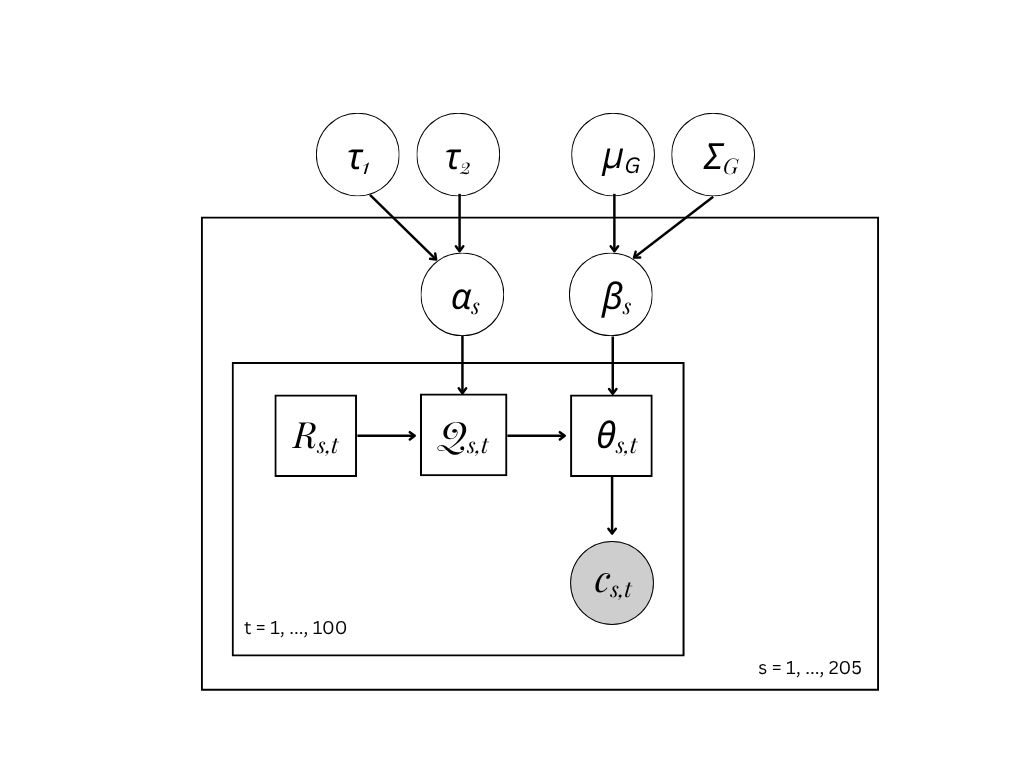

```r
load("model_M2.RData")
model_M2$model
```

```
## JAGS model:
##
## model {
##
##   # ======== Group-Level Priors (Hyperpriors) ========
##
##   # Beta distribution shape parameters (for alpha) ~ Half-Cauchy(0, 25)
##   tau1 ~ dnorm(0, 1 / pow(25, 2)) T(0, )  # approximated by truncated normal
##   tau2 ~ dnorm(0, 1 / pow(25, 2)) T(0, )
##
##   # Group mean priors for b0 and b1 (bias and inverse temperature)
##   betaG[1] ~ dnorm(0, 1 / pow(25, 2))  # mean of b0
##   betaG[2] ~ dnorm(0, 1 / pow(25, 2))  # mean of b1
##
##   # Standard deviations for b0 and b1 (Half-Cauchy approx)
##   lambda[1] ~ dnorm(0, 1 / pow(25, 2)) T(0, )  # SD of b0
##   lambda[2] ~ dnorm(0, 1 / pow(25, 2)) T(0, )  # SD of b1
##
##   # Correlation between b0 and b1
##   rho ~ dunif(-1, 1)
##
##   # Construct covariance matrix SigmaG
##   for (i in 1:2) {
##     for (j in 1:2) {
##       Omega[i,j] <- ifelse(i == j, 1, rho)
##       SigmaG[i,j] <- lambda[i] * lambda[j] * Omega[i,j]
##     }
##   }
##
##   # Convert to precision matrix for multivariate normal
##   tau_beta[1:2, 1:2] <- inverse(SigmaG)
##
##   # ======== Subject-Level Model ========
##
##   for (s in 1:NS) {
##
##     # Learning rate (subject-specific)
##     alpha[s] ~ dbeta(tau1, tau2)
##
##     # Choice parameters from multivariate normal
```

[output cut: 29 more lines]

```
##       V[s, t] <- Q[s, stim_id[s, t], 1, t] - Q[s, stim_id[s, t], 2, t]
##
##       # Softmax choice model (logistic regression)
##       logit(p[s, t]) <- b0[s] + b1[s] * V[s, t]
##
##       # Observed binary choice (converted to 0/1 outside JAGS)
##       choice_two[s, t] ~ dbern(p[s, t])
##
##       # Posterior predictive simulation
##       choice_pred[s, t] ~ dbern(p[s, t])
##     }
##   }
## }
## Fully observed variables:
##  NC NS NStim NT choice choice_two rew stim_id
```

## Model 3: Hierarchical Q-learning with Stickiness

To better capture the cognitive dynamics underlying individual decision-making, **Model 3 (M3)** extends the previous hierarchical Q-learning model by adding a **stickiness parameter** $\kappa$. This addition allows us to model each subject’s tendency to **repeat previous choices**, regardless of the observed outcome.

- $\alpha_s$: the **learning rate**, governing how strongly prediction errors update value estimates;
- $\beta_{1,s}$: the **inverse temperature**, controlling sensitivity to value differences;
- $\beta_{0,s}$: the **baseline choice bias**;
- $\kappa_s$: the **stickiness parameter**, quantifying the effect of the previous choice on the current one.

The parameter $k$ is meant to capture the effect of stickiness, since it scales the influence of action repetition on the current choice probability. A positive value of $k$ implies a bias toward repeating left choices, whereas a negative value favors repetition of right choices.

These are modeled hierarchically:

$$\begin{aligned}
\alpha_s &\sim \text{Beta}(\tau_1, \tau_2) \\
\boldsymbol{\beta}_s =
\begin{bmatrix}
\beta_{0,s} \\
\beta_{1,s} \\
\kappa_s
\end{bmatrix}
&\sim \mathcal{N}_3(\boldsymbol{\mu}_\beta, \Sigma_\beta)
\end{aligned}$$

The covariance matrix $\Sigma_\beta$ is estimated using a weakly informative inverse-Wishart prior on its **precision** $\tau_\beta$, allowing for possible correlations between $\beta_0$, $\beta_1$, and $\kappa$ across individuals:

$$\tau_\beta \sim \text{Wishart}(R, \nu), \quad \Sigma_\beta =
\tau_\beta^{-1}$$

#### Softmax Choice Rule with Stickiness

Incorporating stickiness into the choice model, the softmax function becomes:

$$\text{logit}(p_{s,t}) = \beta_{0,s} + \beta_{1,s} \cdot \left(Q_{s,t}(1)
- Q_{s,t}(2)\right) + \kappa_s \cdot \text{stick}_{s,t}$$

Here:

- $Q_{s,t}(a)$ is the estimated value of action $a$ at time $t$ for subject $s$,
- $\text{stick}_{s,t} \in {-0.5, +0.5}$ encodes whether the subject repeated their previous choice,
- The parameter $\kappa_s$ **increases the likelihood of repeating the previous action when positive**.
  - If $k > 0$, it means subjects are more likely to repeat the left choice.
  - If $k < 0$, it indicates a tendency to repeat the right choice.
  - If $k \approx 0$, no stickiness bias is detected.

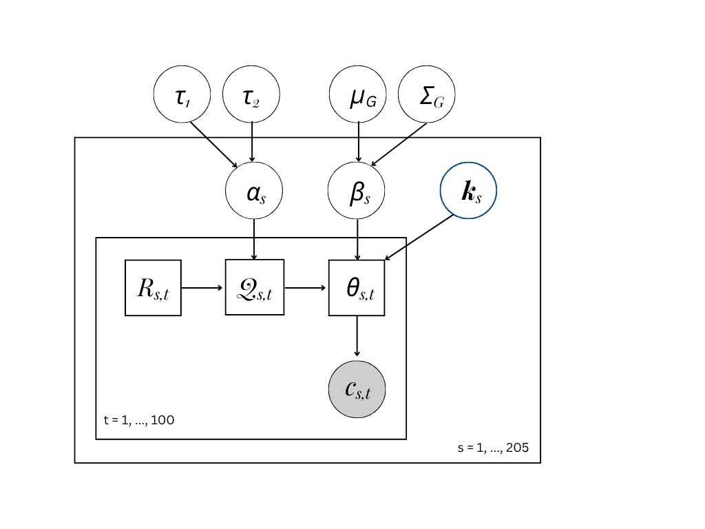

```r
load("model_M3.RData")
model_M3$model
```

```
## JAGS model:
##
## model {
##
##   # ======== Group-Level Priors (Hyperpriors) ========
##
##   # Beta distribution shape parameters (for alpha) - Fixed for simplicity as requested
##   tau1 <- 1
##   tau2 <- 1
##
##   # Group mean priors for b0, b1, and kappa (bias, inverse temperature, stickiness)
##   betaG[1] ~ dnorm(0, 1 / pow(10, 2))  # mean of b0
##   betaG[2] ~ dnorm(0, 1 / pow(10, 2))  # mean of b1
##   betaG[3] ~ dnorm(0, 1 / pow(10, 2))  # mean of kappa
##
##   # Precision matrix for multivariate normal prior on beta (b0, b1, kappa)
##   # Using a Wishart prior for the precision matrix (tau_beta)
##   # R is the scale matrix, nu is the degrees of freedom.
##   # We need to construct R as an identity matrix within JAGS.
##   nu <- 4 # degrees of freedom = number of parameters (3) + 1
##
##   # Manually construct the identity matrix for R
##   for (i in 1:3) {
##     for (j in 1:3) {
##       R[i,j] <- ifelse(i == j, 0.1, 0) # Diagonal elements 0.1, off-diagonal 0
##     }
##   }
##
##   tau_beta[1:3, 1:3] ~ dwish(R[ , ], nu)
##   SigmaG[1:3, 1:3] <- inverse(tau_beta[ , ]) # Covariance matrix (derived for monitoring)
##
##
##   # ======== Subject-Level Model ========
##
##   for (s in 1:NS) {
##
##     # Learning rate (subject-specific)
##     alpha[s] ~ dbeta(tau1, tau2)
##
##     # Choice parameters from multivariate normal
```

[output cut: 30 more lines]

```
##       V[s, t] <- Q[s, stim_id[s, t], 1, t] - Q[s, stim_id[s, t], 2, t]
##
##       # Softmax choice model with stickiness
##       logit(p[s, t]) <- b0[s] + b1[s] * V[s, t] + kappa[s] * stickiness[s, t]
##
##       # Observed binary choice (converted to 0/1 outside JAGS)
##       choice_two[s, t] ~ dbern(p[s, t])
##
##       # Posterior predictive simulation
##       choice_pred[s, t] ~ dbern(p[s, t])
##     }
##   }
## }
## Fully observed variables:
##  NC NS NStim NT choice choice_two rew stickiness stim_id
```

# Inferential Findings

## Model 1 - Analysis

```r
library(R2jags)

params <- c("alpha", "b0", "b1", "choice_pred")

data12 <- list("NS" = 205,
             "MT" = 100,
             "NStim" = 4,
             "NC" = 2,
             "NT" = trialNum_Gershman,
             "stim_id" = state_Gershman,
             "rew" = reward_Gershman,
             "choice" = choice_Gershman,
             "choice_two" = choice_two_Gershman)


model_M1 <- jags(data = data12,
                   parameters.to.save = params,
                   model.file = "Non_hierarchicalM1.jags",
                   n.chains = 3,
                   n.iter = 5000,
                   n.burnin = 1000,
                   n.thin = 3)
```

From the output of the jags model we can directly assess our posterior point and interval summaries as follows:

Point Estimates and 95% CI for Model Parameters (Alpha, b0, b1)

|  | Posterior Mean | Posterior SD | Lower 95% CI | Upper 95% CI | Rhat | ESS |
| --- | --- | --- | --- | --- | --- | --- |
| alpha | 0.486 | 0.024 | 0.439 | 0.535 | 1.001 | 4000 |
| b0 | 0.010 | 0.014 | -0.018 | 0.040 | 1.001 | 2900 |
| b1 | 1.774 | 0.063 | 1.654 | 1.899 | 1.001 | 4000 |

```
## [1] "M1 DIC: "         "25991.3745648255"
```

### M1 Convergence diagnostic

Before delving deeper in the analysis, we must assess wheather the model has convergenced:

- The model **converged** well, as indicated by the **Gelman–Rubin** $\hat{R} \approx 1.00$ for all parameters. This strongly indicates that the MCMC chains for $\alpha$, $b_0$, and $b_1$ have mixed well and converged to the same target posterior distribution. We can trust that the samples from the different chains are providing consistent estimates of the posterior.
- The **Deviance Information Criterion (DIC)** is 25991.4
- The **n.eff** values are quite large. This indicates we have a sufficient number of independent samples to obtain reliable and stable estimates of your posterior means, standard deviations, and credible intervals.
- We can visualize **trace plot** of the sampled values of each parameter against the iteration number for all chains:

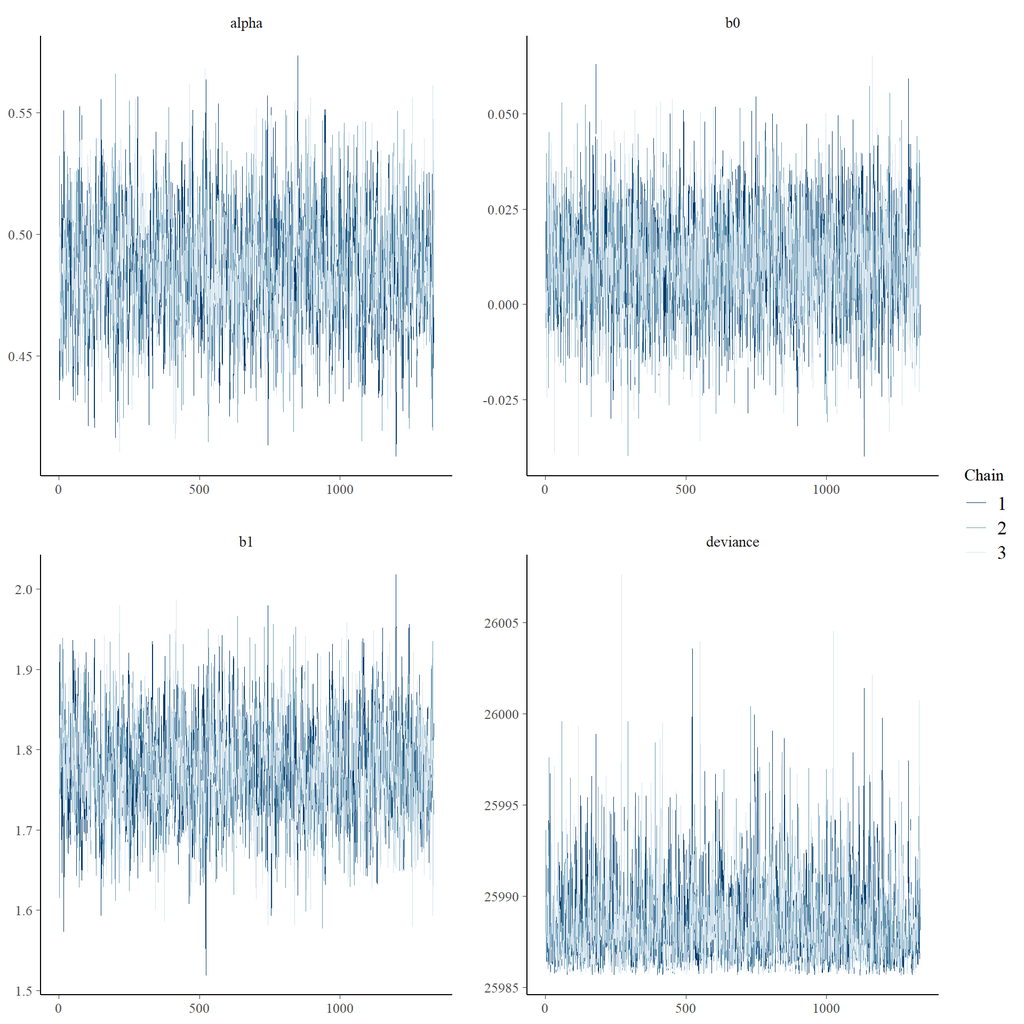

For all parameters, the visualization reassures us of good mixing

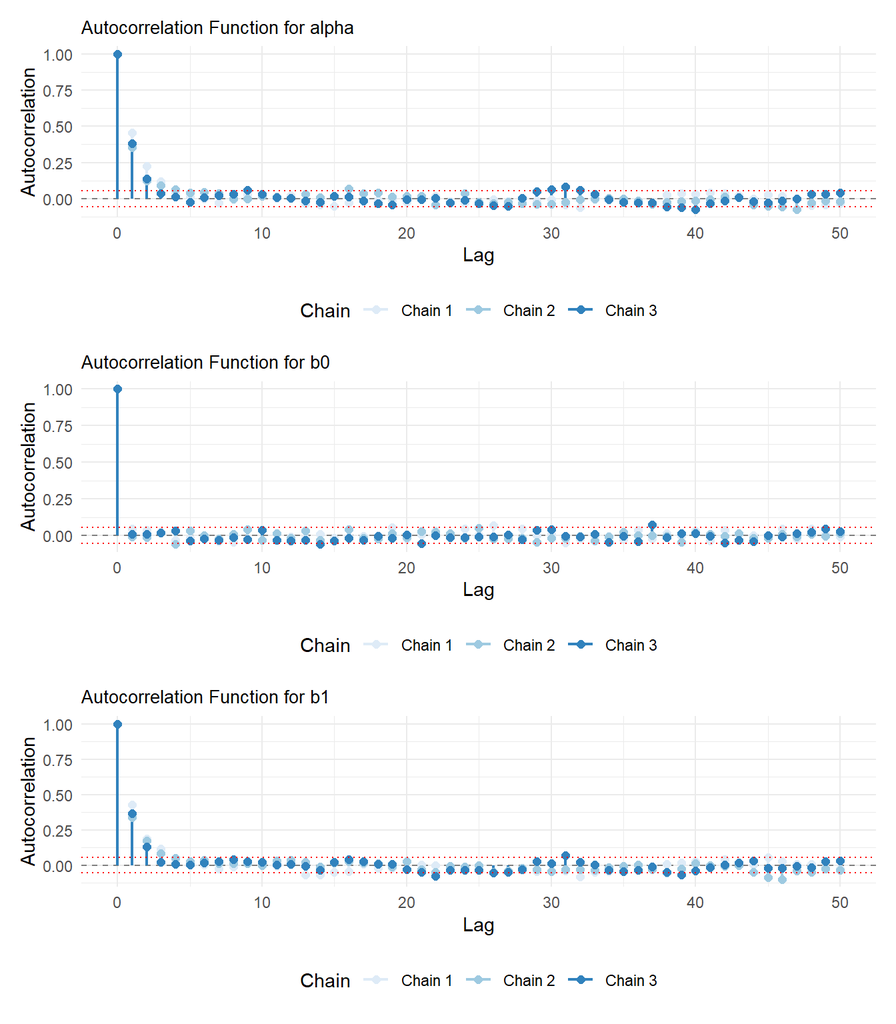

### M1 Posterior Predictive Checks

We then compared these simulated choices to the actual observed data (e.g., the proportion of left choices across trials) to determine whether the model captures the structure and variability present in human decisions. A good fit would imply that the model is capable of replicating empirical behavior and thus provides a meaningful account of the learning and decision-making processes.

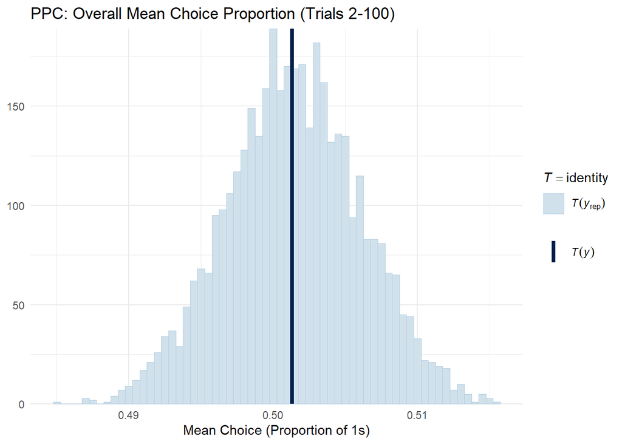

The histograms shows the **posterior predictive distribution** of the overall mean choice proportion. It represents the range of overall mean choice proportions that Model M1, with its estimated parameters, expects to see if you were to generate new data.

The observed mean (vertical line) falls almost perfectly in the center and highest density region of the histogram (simulated means).

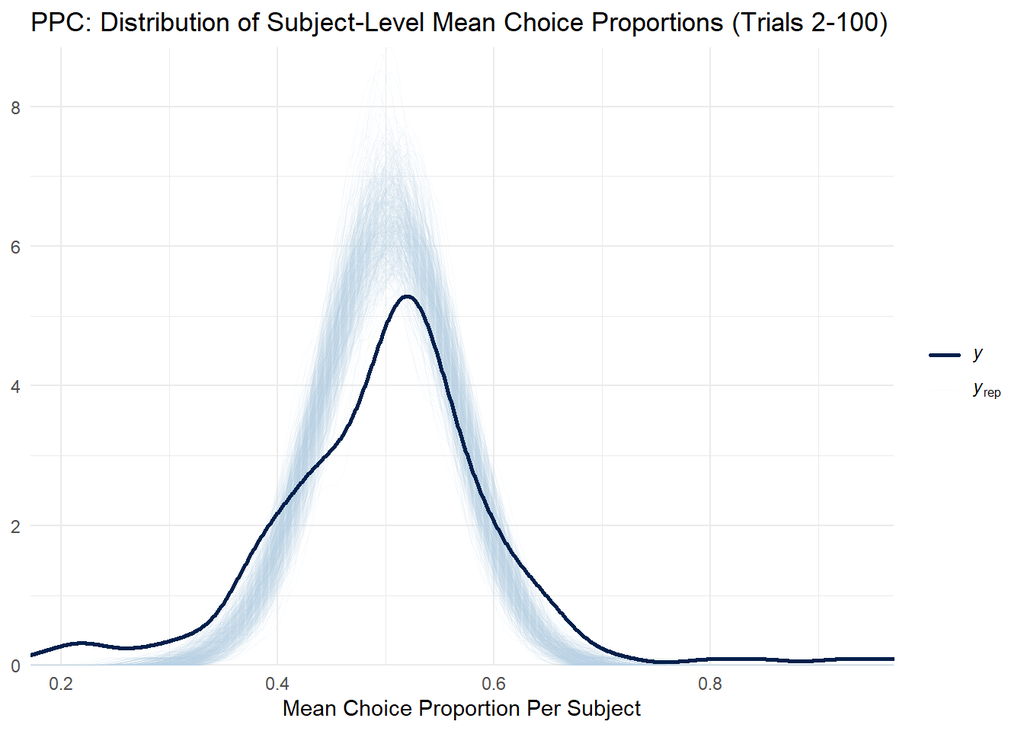

### M1 Results

Now that we have assessed the posterior predictive power of the model, thus the reliability of its posterior estimates, we can answer to the main questions emerged while exploring the dataset:

- **Q.1 Is learning happening at all?**

  Model 1 provides a group-level answer, steaming from the oversimplification of adopting one common cognitive Q-model for all subjects.

  We can address and quantify this question by Hypothesis Testing:
  $$\mathbb{H}_0 \quad \alpha = 0 \quad\text{
  (no learning) vs }\quad \mathbb{H}_1:\quad \alpha > 0\quad
  \text{(learning)}$$

```r
  mean(model_M1$BUGSoutput$sims.list$alpha > 0)
```

```
## [1] 1
```

The learning rate $\alpha$ is always non zero, implying the subjects learn trial by trial.

- **Q.2 Are the subjects learning fast?** Hypothesis:
  $$\mathbb{H}_0:\quad \alpha \leq 0.5\quad
  \text{ vs } \quad \mathbb{H}_1: \quad \alpha > 0.5$$

```r
mean(model_M1$BUGSoutput$sims.list$alpha > 0.5)
```

```
## [1] 0.283821
```

- **Q.3 Is there choice sensitivity ?** (inverse temperature > 0)

Hypothesis:
$$\mathbb{H}_0:\quad \beta_1 =
0 \quad \text{(completely random choice ) vs }\quad \mathbb{H}_1:
\beta_1 > 0$$

```r
# choice sensitivity ht
mean(model_M1$BUGSoutput$sims.list$b1 > 0)
```

```
## [1] 1
```

$\beta_1$ is clearly above 0, which means participants are more likely to choose higher-valued options — a key marker of rational behavior under reinforcement learning.

- **Q.4 Is there a side bias?** (intercept $\neq$ 0) Hypothesis:
  $$\mathbb{H}_0:\quad \beta_0 = 0 \quad\text{ (no
  bias toward left/right) vs }\quad \mathbb{H}_1:\quad \beta_0 \neq
  0$$

```r
# side bias ht
mean(model_M1$BUGSoutput$sims.list$b0 > 0)
```

```
## [1] 0.7614404
```

A more flexible hierarchical model (Model 2) allows individual-level estimation of $\beta_0$, and is therefore better suited to capturing such heterogeneity.

## Model 2 - Analysis

```r
params <- c("alpha", "beta", "betaG", "lambda", "rho", "choice_pred")
model_M2 <- jags(data = data12,
                 parameters.to.save = params,
                 model.file = "Hierarchical_M2.jags",
                 n.chains = 3,
                 n.iter = 5000,
                 n.burnin = 1000,
                 n.thin = 3)
```

### M2 Convergence Diagnostic

To provide a primary evidence for the overall convergence and stability of the M2 MCMC model we might examine Rhat, neff, DIC and traceplots. Differently from the previous M1 model, we will now focus on deviance and hyperparameters’ traceplots, in order to assess good mixing in group-level parameters.

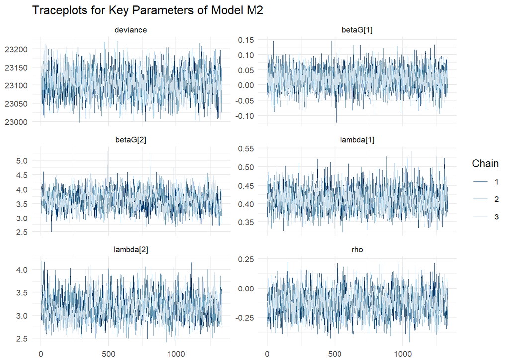

```
##
## DIC for Model M2: 23767.5
##
## Summary diagnostics for Model M2:
##  Parameter  Rhat Rhat_UpperCI  n_eff
##   deviance 1.002        1.004 1429.2
##   betaG[1] 1.001        1.003 3299.9
##   betaG[2] 1.010        1.038  573.0
##  lambda[1] 1.004        1.015 1942.1
##  lambda[2] 1.001        1.003 1383.8
##        rho 1.002        1.005 1307.7
```

#### Autocorrelation

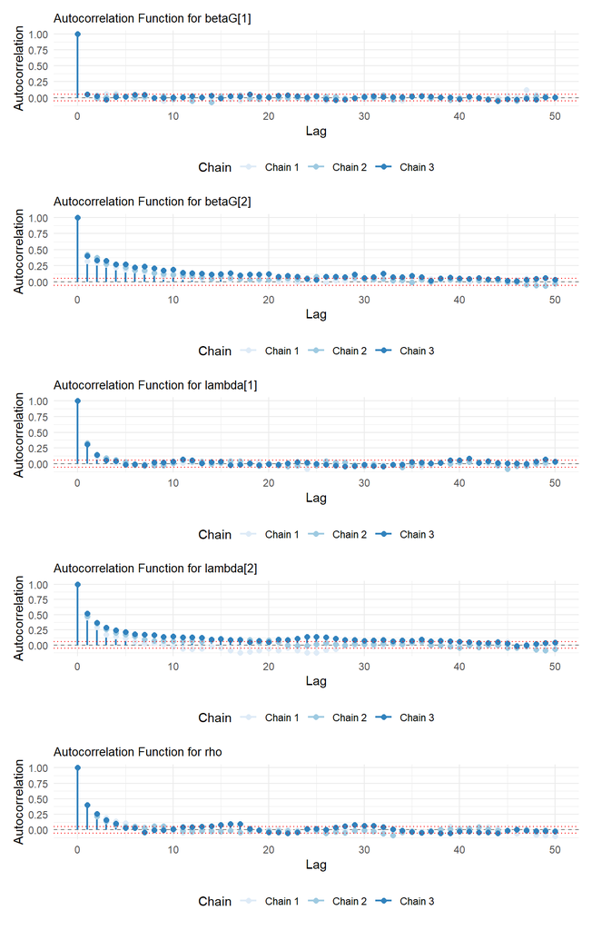

### M2 Posterior Predictive checks

Following M1 PPC, from a hierarchical model we expect an enhanced predictive capability, given by the advantage of modelling each subject cognitive strategy individually.

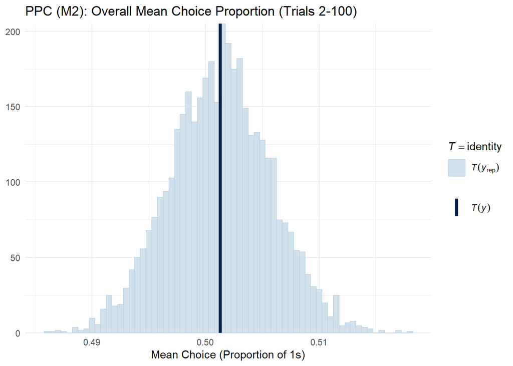

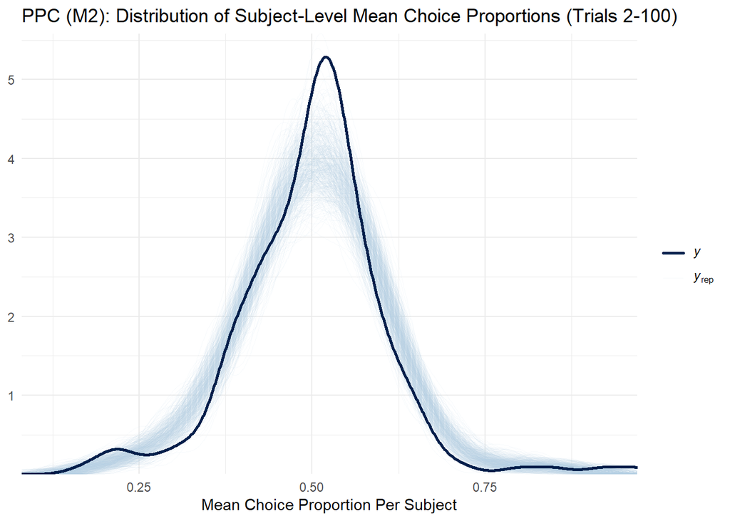

Based on the Posterior Predictive Checks for mean choice proportions, we observe a clear progression in model fit. There is a noticeable improvement in how well the predicted distribution aligns with the observed distribution when moving from Model 1 to Model 2.

### M2 Results

Following the convergence diagnostics and posterior predictive checks for Model 2 (M2) – which notably showed an improved fit compared to Model 1 in predicting subject-level choice proportions – we now turn to its inferential results. This section presents the posterior distributions of the key subject-level parameters estimated by M2: the learning rate, the intercept or bias, and the sensitivity to value differences (b). We first visualize the overall distribution of these parameters across subjects using histograms of their posterior means, followed by caterpillar plots that provide a more granular view of each individual’s estimated parameter value and its associated 95% credible interval.

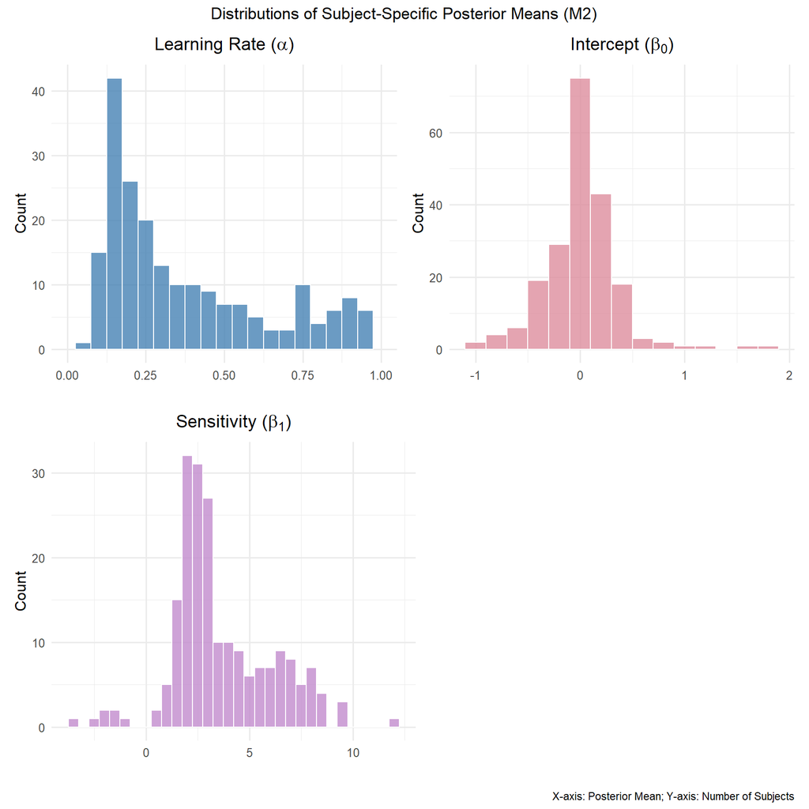

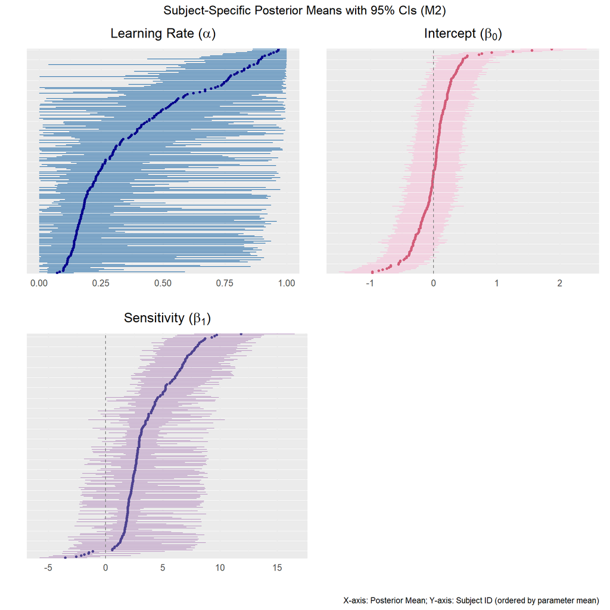

#### Bias ($\beta_0$)

The histogram for the subject-specific bias reveals a distribution centered broadly around zero, but with tails extending to both positive and negative values. This aligns with our initial exploratory data analysis of individual choice proportions, which indicated that subjects exhibited a range of baseline preferences. The caterpillar plot for $\beta_0$ further elucidates this by showing that some subjects indeed possess a discernible preference towards one choice (e.g., a “Left” bias corresponding to a positive $\beta_0$ mean, or a “Right” bias for a positive $\beta_0$ mean), while the majority of individuals exhibit a very small or negligible intrinsic bias, with their 95% credible intervals often encompassing zero. This highlights the model’s ability to differentiate between **truly biased** individuals and those whose baseline choices are **closer to random**.

#### Sensitivity ($\beta_1$)

Each dot in the caterpillar plots indicates the most probable value for that parameter for a specific subject, based on their data and the hierarchical pooling. Shorter horizontal lines (95% CI) indicate more precise estimates. This variability in uncertainty across subjects is natural, as some subjects might have more informative data than others. While showing individual estimates, the credible intervals are implicitly influenced by the group-level distributions. Estimates for subjects with less data or more noise will be “shrunk” more towards the population mean, resulting in more robust and regularized estimates than would be possible with independent non-hierarchical analyses

## Model 3 - Analysis

Model 3 was estimated using $3$ MCMC chains with $5,000$ iterations each ($1,000$ burn-in). It provides an extention of the previous model by accounting for choice repetition behavior, as coded by the stickiness additional parameter

```r
# DATALIST WITH STICKINESS X M3

data3 <- list(
  "NS" = 205,
  "NStim" = 4,
  "NC" = 2,
  "NT" = trialNum_Gershman,
  "K" = 3,
  "stim_id" = state_Gershman,
  "rew" = reward_Gershman,
  "choice" = choice_Gershman,
  "choice_two" = choice_two_Gershman,
  "stickiness" = stickiness_Gershman
)


#  parameters to save
params3 <- c(
  "alpha",
  "b0",
  "b1",
  "kappa",
  "choice_pred",
  "betaG",
  "tau_beta",
  "SigmaG"
)

model_M3 <- jags(data = data3,
               parameters.to.save = params3,
               model.file = "justanotherM3.jags",
               n.chains = 3,
               n.iter = 5000,
               n.burnin = 1000,
               n.thin = 5)
```

### M3 Convergence Diagnostic

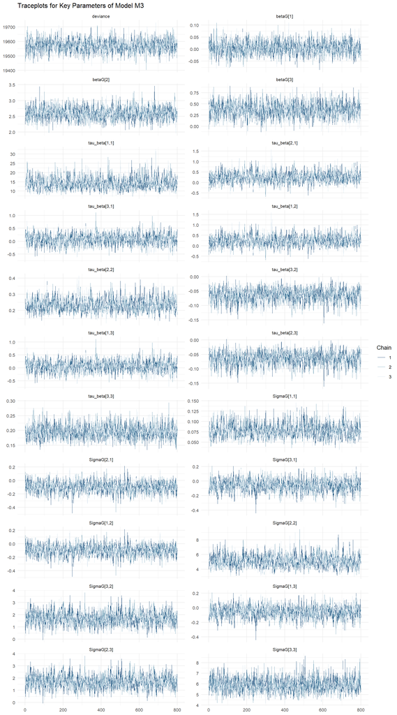

```
##
## DIC for Model M3: 20526.02
##
## Summary diagnostics for Model M3:
##      Parameter  Rhat Rhat_UpperCI  n_eff
##       deviance 1.001        1.003 1389.0
##       betaG[1] 1.000        1.002 1995.7
##       betaG[2] 1.009        1.030 1557.8
##       betaG[3] 1.000        1.001 2274.4
##  tau_beta[1,1] 1.000        1.003 1129.0
##  tau_beta[2,1] 1.002        1.007 1152.0
##  tau_beta[3,1] 1.001        1.005 1170.3
##  tau_beta[1,2] 1.002        1.007 1152.0
##  tau_beta[2,2] 1.009        1.029  868.0
##  tau_beta[3,2] 1.004        1.015 1308.5
##  tau_beta[1,3] 1.001        1.005 1170.3
##  tau_beta[2,3] 1.004        1.015 1308.5
##  tau_beta[3,3] 1.010        1.023 1966.5
##    SigmaG[1,1] 1.000        1.002  992.8
##    SigmaG[2,1] 1.002        1.009 1221.0
##    SigmaG[3,1] 1.000        1.003 1272.7
##    SigmaG[1,2] 1.002        1.009 1221.0
##    SigmaG[2,2] 1.007        1.026  832.3
##    SigmaG[3,2] 1.009        1.032 1322.7
##    SigmaG[1,3] 1.000        1.003 1272.7
##    SigmaG[2,3] 1.009        1.032 1322.7
##    SigmaG[3,3] 1.004        1.007 1932.8
```

The traceplots for Model 3’s group-level hyperparameters, specifically the population means ($\beta_G$) and the components of the covariance matrix (_G), demonstrate excellent mixing. Despite the increased complexity of the multivariate prior, all chains show robust stationarity and efficient exploration of the parameter space, confirming that the model has successfully converged and is adequately sampling from these high-dimensional posterior distributions.

### M3 Posterior Predictive Checks

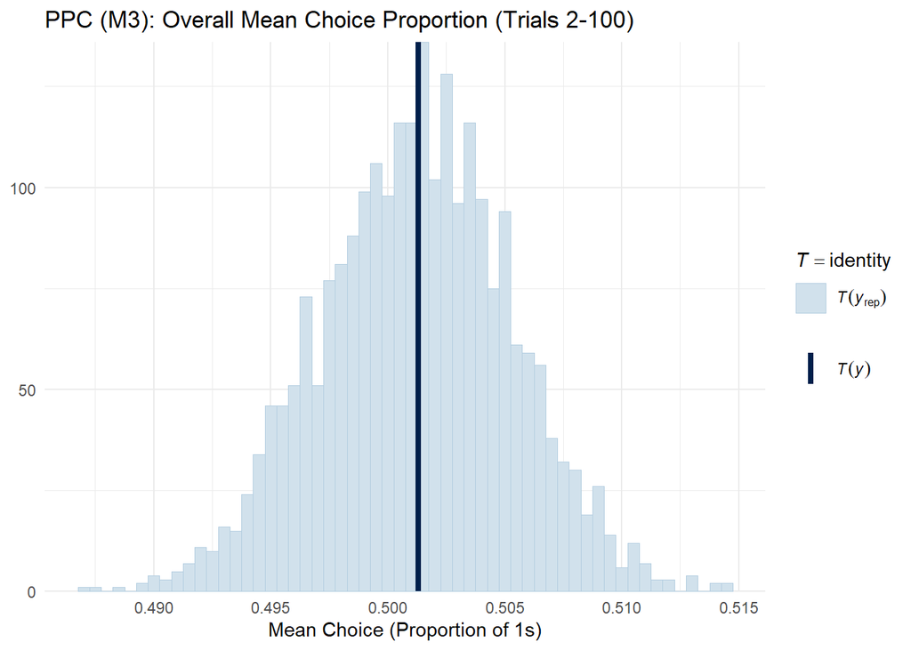

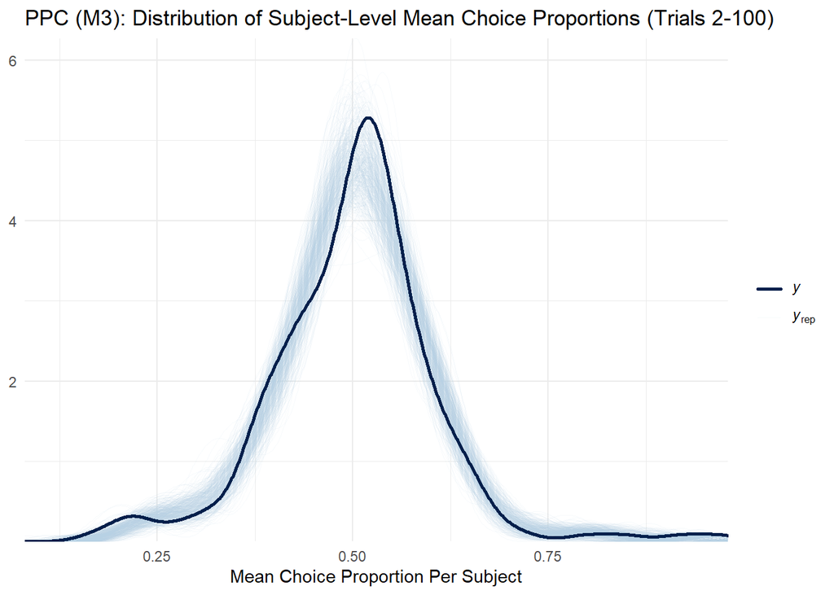

Crucially, Model 3 further outperforms both Model 1 and Model 2, demonstrating the strongest agreement between its simulated mean choice proportions and the actual observed data. This indicates that Model 3 provides the most accurate and faithful representation of the decision-making process captured in the data, reflecting its enhanced complexity and hierarchical structure.

### M3 Results

Having confirmed the convergence and satisfactory mixing of Model 3 (M3) through diagnostic plots, we now delve into its inferential findings, particularly focusing on the subject-level parameter estimates. Unlike Model 2, M3 additionally estimates a stickiness parameter ($k$) for each subject and models the relationship between bias ($b_0$), inverse temperature ($b_1$), and stickiness ($k$) at the group level. The following plots visualize the distributions of the posterior means for each subject-specific parameter via histograms, and provide a detailed view of individual parameter estimates and their 95% credible intervals through caterpillar plots. These visualizations allow us to gain insight into the range of individual differences and the precision of our parameter estimates within the population.

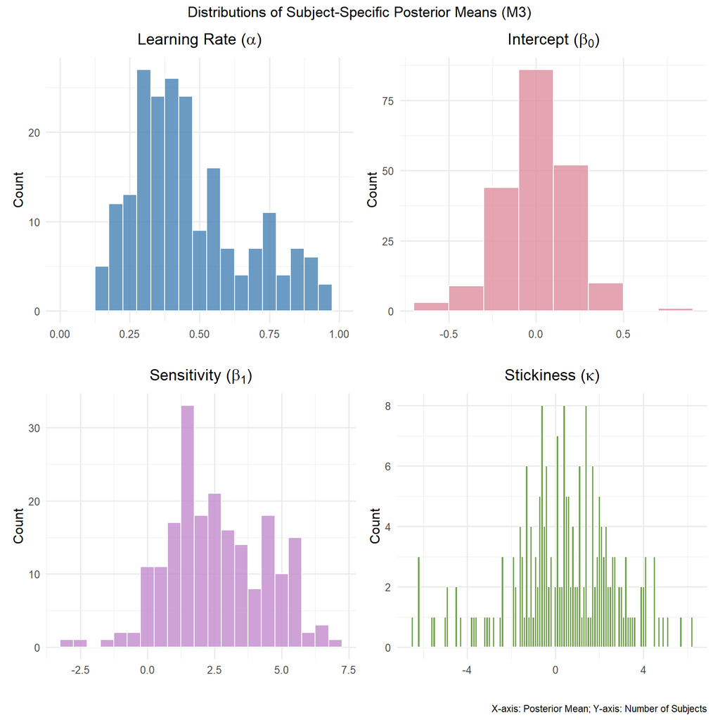

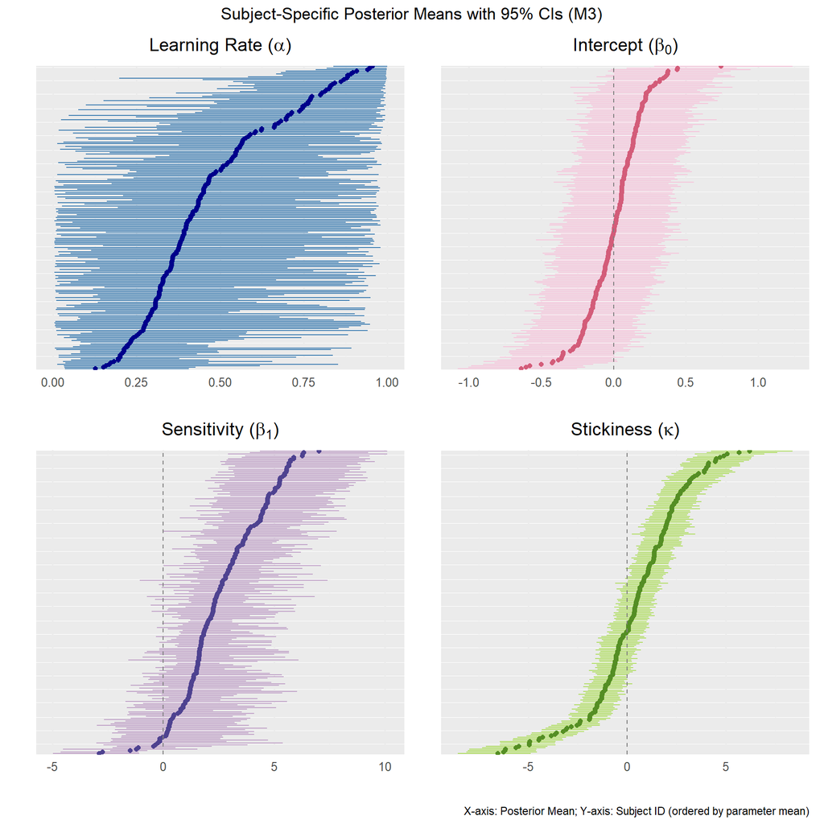

# Model Comparison

We can start comparing the models using Deviance Information Criterion — lower values suggest better out-of-sample predictive fit.

Deviance Information Criterion (DIC) for Models M1, M2, and M3

| Model | DIC |
| --- | --- |
| M1 | 25991.37 |
| M2 | 23767.50 |
| M3 | 20526.02 |

The lower DIC for the hierarchical model (M2) with respect to the non hierarchical one (M1) indicates that accounting for individual variability improves model performance.

The enhanced M3 model, which accounts for the additional parameter of stickiness, achieves the best overall DIC.

## Reward Recovery

This step helps validate that the estimated learning parameters lead to behavior that is consistent with the actual reward environment.

We use the posterior means of the subject-specific parameters estimated by M2 and M3 to simulate behavior on the same sequence of trials each subject experienced. For each trial, we simulate choices and rewards using:

- the Q-learning update rule with subject-specific $\alpha$,
- a softmax decision rule with subject-specific $\beta_0$ and $\beta_1$ for M2, $\beta_0$ and $\beta_1$ and $\kappa$ for M3,
- the true reward probabilities recorded in the dataset.

We then compare the **simulated behavior** (i.e., the reward rates obtained under simulated choices) with the **true reward probabilities** used in the experiment. A close correspondence between the two would indicate that the model successfully internalizes the structure of the task and recovers the latent reward contingencies.

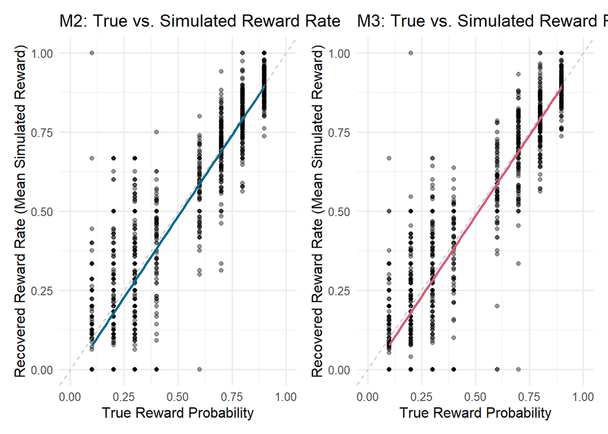

The X-axis represents the True Reward Probability, which is the inherent likelihood of receiving a reward for a given action in the simulated trials. The Y-axis, Recovered Reward Rate, shows the average reward observed across simulated subjects for each corresponding true probability.

The blue and pink regression lines, respectively for M2 and M3, which trace the **mean of the simulated data points**, closely aligns with the diagonal ($y = x$).

This indicates that, **on average, both models effectively recover the true underlying reward probabilities**.

The vertical spread of the individual grey and black data points around the blue line at each true reward probability demonstrates the inherent variability in simulated reward rates across different simulated subjects. This spread is expected and reflects several factors:

- Individual Parameter Differences: Each simulated subject operates with their own distinct set of alpha, b0, and b1 parameters (drawn from the posterior distributions), leading to varied learning and decision-making strategies.
- Stochasticity of Choices and Rewards: The simulation process incorporates random elements (e.g., rbinom for choices and rewards), meaning that even subjects with identical parameters, exposed to the same true probability, will experience slightly different reward sequences due to chance.

When comparing M2 and M3, both models show good alignment with the $y=x$ line, suggesting that the additional complexity of stickiness in M3 does not impede its ability to faithfully represent the fundamental reward probabilities of the environment. The consistency of this recovery across both models provides confidence that their respective parameter sets allow for the generation of ecologically valid reward feedback within the simulated environment.

# Frequentist Comparative Analysis

This section presents a frequentist analysis using a **Generalized Linear Mixed Model** (GLMM) to analyze the behavioral choice data, serving as a critical validation of the findings from the preceding Bayesian hierarchical model (Model M3).

Trial-by-trial Q-values, derived using each participant’s individual learning rate (alpha) obtained from the Bayesian Model M3, are incorporated as a key **predictor of choice**. The GLMM examines how decision-making is influenced by these learned value differences and by ‘choice stickiness’ (previous trial’s choice), while accounting for individual variability through random effects.

By comparing the GLMM’s fixed effects, random effects, and model fit criteria with their Bayesian counterparts, we assess the robustness and consistency of our reinforcement learning model’s parameters across these two distinct statistical frameworks.

```
##   Assigned names to alpha_s_M3 based on unique subject IDs in rl_data.
```

```
##   Alpha values successfully mapped for 205 subjects.
```

```
##   GLMM fitting complete. Summary:
```

```
## Generalized linear mixed model fit by maximum likelihood (Laplace
##   Approximation) [glmerMod]
##  Family: binomial  ( logit )
## Formula: choice_two ~ value_difference + prev_choice + (1 + value_difference +
##     prev_choice | subject_ID)
##    Data: merged_data_for_glmm
## Control: glmerControl(optimizer = "bobyqa", optCtrl = list(maxfun = 2e+05))
##
##       AIC       BIC    logLik -2*log(L)  df.resid
##   21060.1   21131.5  -10521.1   21042.1     20491
##
## Scaled residuals:
##     Min      1Q  Median      3Q     Max
## -6.3532 -0.6382  0.0912  0.6294  7.9742
##
## Random effects:
##  Groups     Name             Variance Std.Dev. Corr
##  subject_ID (Intercept)      1.446    1.203
##             value_difference 4.313    2.077    -0.31
##             prev_choice      5.547    2.355    -0.97  0.29
## Number of obs: 20500, groups:  subject_ID, 205
##
## Fixed effects:
##                  Estimate Std. Error z value Pr(>|z|)
## (Intercept)      -0.13345    0.08839  -1.510   0.1311
## value_difference  2.37830    0.16187  14.693   <2e-16 ***
## prev_choice       0.31664    0.16923   1.871   0.0613 .
## ---
## Signif. codes:  0 '***' 0.001 '**' 0.01 '*' 0.05 '.' 0.1 ' ' 1
##
## Correlation of Fixed Effects:
##             (Intr) vl_dff
## valu_dffrnc -0.254
## prev_choice -0.951  0.237
```

```
##  Conducting Comparative Analysis (Bayesian vs. Frequentist)
```

```
## --- 1. Comparison of Population-Level (Fixed) Effects ---
```

```
## Frequentist Fixed Effects (Estimates for b0_Intercept, b1_ValueDifference, kappa_PrevChoice equivalents):
```

```
##      (Intercept) value_difference      prev_choice
##       -0.1334548        2.3782965        0.3166411
```

```
##
## Bayesian Group Means (betaG from M3):
```

```
##      (Intercept) value_difference      prev_choice
##       0.00617368       2.59509792       0.37132501
```

```
##
## Differences (Frequentist Estimate - Bayesian Mean) for aligned parameters:
```

```
##      (Intercept) value_difference      prev_choice
##      -0.13962852      -0.21680145      -0.05468395
```

```
## --- 2. Comparison of Intervals ---
```

```
## Frequentist 95% Confidence Intervals:
```

```
##          Parameter Lower_CI_Freq Upper_CI_Freq
## 1      (Intercept)   -0.30669963    0.03978996
## 2 value_difference    2.06103696    2.69555597
## 3      prev_choice   -0.01505176    0.64833390
```

```
##
## Bayesian 95% Credible Intervals:
```

```
##          Parameter Lower_CI_Bayes Upper_CI_Bayes
## 1      (Intercept)    -0.04697656     0.06169909
## 2 value_difference     2.20934521     3.00153622
## 3      prev_choice     0.03834156     0.70516516
```

```
## --- 3. Comparison of Individual Differences (Random Effects) ---
```

```
## Frequentist Random Effects (Variances, Std.Dev., and Correlations from VarCorr):
```

```
##          grp             var1             var2       vcov      sdcor
## 1 subject_ID      (Intercept)             <NA>  1.4464945  1.2027030
## 2 subject_ID value_difference             <NA>  4.3125222  2.0766613
## 3 subject_ID      prev_choice             <NA>  5.5467147  2.3551464
## 4 subject_ID      (Intercept) value_difference -0.7844747 -0.3140905
## 5 subject_ID      (Intercept)      prev_choice -2.7515831 -0.9714184
## 6 subject_ID value_difference      prev_choice  1.4230749  0.2909673
```

```
##
## Bayesian Group-Level Covariance Matrix (SigmaG mean from M3):
```

```
##                  (Intercept) value_difference prev_choice
## (Intercept)       0.07825129      -0.09657173 -0.05943221
## value_difference -0.09657173       5.10044586  1.68344619
## prev_choice      -0.05943221       1.68344619  5.90230544
```

```
##
## Bayesian Group-Level Correlation Matrix (from SigmaG mean):
```

```
##                  (Intercept) value_difference prev_choice
## (Intercept)        1.0000000       -0.1528622  -0.0874511
## value_difference  -0.1528622        1.0000000   0.3068205
## prev_choice       -0.0874511        0.3068205   1.0000000
```

```
##
## Bayesian Posterior Mean Correlation (Value Sensitivity [b1] vs Stickiness [kappa]): 0.307
```

```
## Bayesian 95% CI for Correlation: 0.129 0.472
```

```
## --- 4. Comparison of Model Fit Criteria ---
```

```
## Frequentist Model AIC: 21060.14
```

```
## Frequentist Model BIC: 21131.49
```

```
##
## Bayesian Model DIC: 20526.02
```

This comparison highlights the similarities and differences between the Bayesian and Frequentist approaches:

Important Caveat: The learning rate (alpha) is handled differently. In the GLMM, alpha is pre-computed using Bayesian means, not estimated directly by the GLMM, since it is necessary to pre-compute Q-values before fitting it. This means the GLMM’s estimates for value_difference and prev_choice are conditional on the alpha values from the Bayesian model.